# Date-Time Data Analysis in R

A practical guide to working with date and time data.

Data management

Time series analysis

Author

Habtamu Bizuayehu

Published

April 14, 2025

# **Overview of Presentation Contents**

This presentation introduces essential techniques for analyzing date and time data in health research using R. Key topics include:

- **Importance of date/time analysis**
- **Core R packages** for handling dates (e.g., `lubridate`, `tidyverse`)
- **Date conversion and formatting**
- **Calculating durations and age**
- **Extracting date components** (e.g., month, weekday, season)
- **Summary and Visualize time-based trends**

**1. Importance of Date/Time Analysis in Health Data**

Date-time data is crucial in healthcare because it allows us to:

- Calculate accurate patient ages, service time
- Measure time intervals between critical events (e.g., diagnosis to treatment, age vaccination)
- Identify seasonal patterns in disease occurrence
- Track vaccine effectiveness over time
- Determine follow-up periods for clinical studies

# **Load required libraries**

```r
library(lubridate) # Simplifies the manipulation of dates and times in R (e.g., formatting, extracting components)
library(dplyr) # Provides tools for data manipulation, helpful for filtering and summarizing date-based data
library(stringr) # Simplifies string manipulation

library(zoo) # For working with time series data, including rolling calculations and handling missing data in time series
library(tsibble) # Provides tools for handling time series data, including date-time indexes and features for forecasting

library(readr) # For reading date-time data from CSV
library(haven) #  data from other statistical software formats (SPSS, SAS, Stata)
library(forecast) # Useful for time series forecasting, especially when working with seasonal or trend-based data
library(ggplot2) # For visualizing date-time trends in data (e.g., time series plots)
library(janitor) # Tabulation, cleaning column names, adding totals and proportions
library (plotly)     # Interactive visualizations

# Documentation/reporting
library(prettydoc)  # Pretty document templates
library(flexdashboard)# Interactive dashboards
library(knitr)      # Dynamic report generation
library(quarto)  # For rendering and publishing documents with the Quarto framework
library(rmarkdown)  # R Markdown document processing
library(yaml)       # YAML document processing

# Tabulation
library(flextable)  # Flexible table formatting
library(gt)         # Grammar of tables
library(reactable)  # Interactive tables
```

```r
setwd("C:/Users/User/Desktop/Materials_ Course and proposals/Course Related/DataCamp/Data/Synthetic_data")

patients <- read.csv("patients.csv")
vaccination <- read.csv("immunizations.csv")
```

```r
# Convert column names to lowercase
colnames(patients) <- tolower(colnames(patients))
colnames(vaccination) <- tolower(colnames(vaccination))

# View data
# head(patients)
# head(vaccination)

str(patients)
```

```
'data.frame':   106 obs. of  28 variables:
 $ id                 : chr  "30a6452c-4297-a1ac-977a-6a23237c7b46" "34a4dcc4-35fb-6ad5-ab98-be285c586a4f" "7179458e-d6e3-c723-2530-d4acfe1c2668" "37c177ea-4398-fb7a-29fa-70eb3d673876" ...
 $ birthdate          : chr  "1994-02-06" "1968-08-06" "2008-12-21" "1994-01-27" ...
 $ deathdate          : chr  "" "2009-12-11" "" "" ...
 $ ssn                : chr  "999-52-8591" "999-75-3953" "999-70-1925" "999-27-9779" ...
 $ drivers            : chr  "S99996852" "S99993577" "" "S99995100" ...
 $ passport           : chr  "X47758697X" "X28173268X" "" "X83694889X" ...
 $ prefix             : chr  "Mr." "Mr." "" "Mrs." ...
 $ first              : chr  "Joshua658" "Bennie663" "Hunter736" "Carlyn477" ...
 $ middle             : chr  "Alvin56" "" "Mckinley734" "Florencia449" ...
 $ last               : chr  "Kunde533" "Ebert178" "Gerlach374" "Williamson769" ...
 $ suffix             : logi  NA NA NA NA NA NA ...
 $ maiden             : chr  "" "" "" "Rogahn59" ...
 $ marital            : chr  "M" "D" "" "M" ...
 $ race               : chr  "white" "white" "white" "asian" ...
 $ ethnicity          : chr  "nonhispanic" "nonhispanic" "nonhispanic" "nonhispanic" ...
 $ gender             : chr  "M" "M" "M" "F" ...
 $ birthplace         : chr  "Boston  Massachusetts  US" "Chicopee  Massachusetts  US" "Spencer  Massachusetts  US" "Franklin  Massachusetts  US" ...
 $ address            : chr  "811 Kihn Viaduct" "975 Pfannerstill Throughway" "548 Heller Lane" "160 Fadel Crossroad Apt 65" ...
 $ city               : chr  "Braintree" "Braintree" "Mattapoisett" "Wareham" ...
 $ state              : chr  "Massachusetts" "Massachusetts" "Massachusetts" "Massachusetts" ...
 $ county             : chr  "Norfolk County" "Norfolk County" "Plymouth County" "Plymouth County" ...
 $ fips               : int  25021 25021 NA NA NA 25017 25017 25021 25009 NA ...
 $ zip                : int  2184 2184 0 0 0 2138 2476 2184 1835 0 ...
 $ lat                : num  42.2 42.3 41.6 41.8 42.7 ...
 $ lon                : num  -71 -71 -70.9 -70.7 -71 ...
 $ healthcare_expenses: num  56905 124024 45645 12895 18500 ...
 $ healthcare_coverage: num  18020 1075 6155 659952 5494 ...
 $ income             : int  100511 49737 133816 17382 52159 75767 58294 49737 77756 35255 ...
```

```r
str(vaccination)
```

```
'data.frame':   1619 obs. of  6 variables:
 $ date       : chr  "2016-04-10T09:04:48Z" "2016-04-10T09:04:48Z" "2016-04-10T09:04:48Z" "2016-04-10T09:04:48Z" ...
 $ patient    : chr  "30a6452c-4297-a1ac-977a-6a23237c7b46" "30a6452c-4297-a1ac-977a-6a23237c7b46" "30a6452c-4297-a1ac-977a-6a23237c7b46" "30a6452c-4297-a1ac-977a-6a23237c7b46" ...
 $ encounter  : chr  "0b03e41b-06a6-66fa-b972-acc5a83b134a" "0b03e41b-06a6-66fa-b972-acc5a83b134a" "0b03e41b-06a6-66fa-b972-acc5a83b134a" "0b03e41b-06a6-66fa-b972-acc5a83b134a" ...
 $ code       : int  140 113 43 114 140 140 140 140 140 52 ...
 $ description: chr  "Influenza  seasonal  injectable  preservative free" "Td (adult)  5 Lf tetanus toxoid  preservative free  adsorbed" "Hep B  adult" "meningococcal MCV4P" ...
 $ base_cost  : num  136 136 136 136 136 136 136 136 136 136 ...
```

```r
# Check for missing IDs
patients$id[patients$id == ""] <- NA
print(sum(is.na(patients$id)))
```

```
[1] 0
```

```r
# Check duplicates
patients <- patients %>%
  arrange(id) %>%
  group_by(id) %>%
  mutate(dup = row_number()) %>%
  ungroup()

table(patients$dup)  # Check if any duplicates exist
```

```
  1
106
```

```r
# Merge with vaccination data
vaccination <- vaccination %>% mutate(id = patient)


vacc_pt_merged <- left_join(patients, vaccination, by = "id" )

#vacc_pt_merged <- left_join(patients, vaccination, by = c("id" = "patient"))

str (vacc_pt_merged)
```

[output not shown]

# Converting Character to Date Format

in the dataset `birthdate`, `deathdate`, and `date` (vaccination date) are all stored as character strings. I need to convert these to proper date formats using `lubridate::ymd()`.

```r
# Convert to date format
str (vacc_pt_merged$birthdate)
```

```
 chr [1:1619] "1975-12-24" "1975-12-24" "1975-12-24" "1975-12-24" ...
```

```r
str (vacc_pt_merged$date) # date is YYYY-MM-DD HH:MM:SS format.
```

```
 chr [1:1619] "2015-06-24T14:05:28Z" "2016-06-29T14:05:28Z" ...
```

```r
vacc_pt_merged <- vacc_pt_merged %>%
  mutate(
    birthdate = parse_date(birthdate, format = "%Y-%m-%d"),
    vacc_date = as.Date(strptime(date, format = "%Y-%m-%dT%H:%M:%SZ"))
  )

# Check structure
str (vacc_pt_merged$birthdate)
```

```
 Date[1:1619], format: "1975-12-24" "1975-12-24" "1975-12-24" "1975-12-24" "1975-12-24" ...
```

```r
str (vacc_pt_merged$vacc_date)
```

```
 Date[1:1619], format: "2015-06-24" "2016-06-29" "2016-06-29" "2017-07-05" "2017-07-05" ...
```

```r
# Check converted formats via glimpse
# glimpse(vacc_pt_merged)

# no missing values on dates
sum(is.na(vacc_pt_merged$birthdate))
```

```
[1] 0
```

```r
sum(is.na(vacc_pt_merged$vacc_date))
```

```
[1] 0
```

```r
# Check date ranges
summary(vacc_pt_merged$birthdate)
```

```
        Min.      1st Qu.       Median         Mean      3rd Qu.         Max.
"1914-03-03" "1969-12-09" "1999-02-24" "1990-12-03" "2012-09-02" "2023-03-01"
```

```r
summary(vacc_pt_merged$vacc_date)
```

```
        Min.      1st Qu.       Median         Mean      3rd Qu.         Max.
"1962-12-09" "2017-05-21" "2020-01-04" "2019-04-29" "2022-01-26" "2024-10-26"
```

Now date columns are in Date format (`YYYY-MM-DD`), ready for analysis!

# **Age and Service year Calculation**

```r
vacc_pt_merged <- vacc_pt_merged %>%
  mutate(
    age_years = floor (as.numeric(difftime(Sys.Date(), birthdate, units = "days")) / 365.25),

    # Calculate vaccination service year by extracting the year from vacc_date
   vacc_service_year = year(vacc_date)
  )


summary(vacc_pt_merged$age_years)
```

```
   Min. 1st Qu.  Median    Mean 3rd Qu.    Max.
    2.0    13.0    26.0    34.4    55.0   111.0
```

```r
summary(vacc_pt_merged$vacc_service_year)
```

```
   Min. 1st Qu.  Median    Mean 3rd Qu.    Max.
   1962    2017    2020    2019    2022    2024
```

```r
# tabulation
table(vacc_pt_merged$age_years)
```

```
  2   3   6   7   8  10  11  12  13  14  15  16  17  18  19  20  21  22  24  25
 46  24  64  66  34  72  30  38  59  21  21  51  66  18  36  18  69  13  13  12
 26  28  29  30  31  34  37  38  39  41  42  44  45  46  47  48  49  50  52  53
 47  17  30   9  38  11   6   8   6  27  46   9  17  15  13  18  42  15  13  30
 54  55  56  57  59  61  62  63  65  66  69  70  72  73  75  77  79  81  86  98
 16  15  15  30  14  26  13  62  26  14  14  57  15  27  15  14  12  13  12  20
111
  1
```

```r
table(vacc_pt_merged$vacc_service_year)
```

```
1962 1963 1964 1965 1966 1967 1968 1969 1970 1971 2001 2002 2003 2004 2005 2006
   1    3    1    1    1    2    1    1    1    1    1    2    1    1    2    1
2007 2008 2009 2010 2011 2012 2013 2014 2015 2016 2017 2018 2019 2020 2021 2022
   3    6    2    3    2    4    3   22  153  139  137  151  161  137  263  120
2023 2024
 170  122
```

The **highest frequency of vaccinations** occurred in the year 2021, suggesting a peak in service delivery during that period.

# **Calculating Time Differences**

To calculate time differences, I use `interval()` or simple subtraction between date objects.

Example: Years between birth and vaccination gives the **number of years from birth to vaccination**.

```r
vacc_pt_merged <- vacc_pt_merged %>%
  mutate(
    days_to_vax = as.numeric(vacc_date - birthdate),  # Difference in days
    weeks_to_vax = as.numeric(difftime(vacc_date,  birthdate,  units = "weeks")),  # Difference in weeks
    months_to_vax = as.numeric(difftime(vacc_date,  birthdate,  units = "days")) / 30.44,  # Approximate months (average days per month)
    years_to_vax = floor(as.numeric(difftime(vacc_date,  birthdate,  units = "days")) / 365.25)  # Approximate years (including leap years)
  )


# View summary statistics
summary(vacc_pt_merged$days_to_vax)
```

```
   Min. 1st Qu.  Median    Mean 3rd Qu.    Max.
      0    2548    7742   10375   18263   36813
```

```r
summary(vacc_pt_merged$weeks_to_vax)
```

```
   Min. 1st Qu.  Median    Mean 3rd Qu.    Max.
      0     364    1106    1482    2609    5259
```

```r
summary(vacc_pt_merged$months_to_vax)
```

```
   Min. 1st Qu.  Median    Mean 3rd Qu.    Max.
   0.00   83.71  254.34  340.82  599.97 1209.36
```

```r
summary(vacc_pt_merged$years_to_vax)
```

```
   Min. 1st Qu.  Median    Mean 3rd Qu.    Max.
   0.00    6.00   21.00   28.02   50.00  100.00
```

# **Extracting Date Components**

We will perform the following extractions for both the `birthdate` and `vaccination date`:

1. **Day**: The day of the month is extracted using the `day()` function.
2. **Month**: The month of the date is obtained with the `month()` function. This provides a numeric value (1 for January, 12 for December).
3. **Year**: The year component is retrieved using the `year()` function, returning a four-digit value for the year.
4. **Quarter**: The quarter of the year is extracted using the `quarter()` function, providing a numeric value from 1 to 4, representing the first through fourth quarter of the year.
5. **Season**: Based on the month, we assign a corresponding season (Summer, Autumn, Winter, or Spring) using a conditional `case_when()` function:

These components are useful for segmenting the data, performing seasonal analysis, and understanding how different periods influence the patterns observed in the data. For instance, analyzing vaccination trends by quarter or season can provide valuable insights into public health strategies.

By extracting these components, we are preparing the data for more granular analysis, including cohort analysis, seasonal trend assessments, and other forms of time-based grouping.

```r
vacc_pt_merged <- vacc_pt_merged %>%
  mutate(
    # Basic date components
    vacc_day = day(vacc_date),
    vacc_month = month(vacc_date),
    vacc_month_name = month(vacc_date, label = TRUE, abbr = FALSE),  # Full month name
    vacc_year = year(vacc_date),
    vacc_weekday = wday(vacc_date, label = TRUE, abbr = FALSE),     # Full weekday name
    vacc_week = week(vacc_date),                                    # Week of year
    vacc_quarter = quarter(vacc_date),

    # Fiscal year (assuming June start)
    vacc_fy = ifelse(vacc_month >= 6, vacc_year, vacc_year - 1),

    # Season (Northern Hemisphere)
    vacc_season = case_when(
      vacc_month %in% 3:5 ~ "Spring",
      vacc_month %in% 6:8 ~ "Summer",
      vacc_month %in% 9:11 ~ "Autumn",
      TRUE ~ "Winter"  # December-February
    ),

    # Weekend flag
    is_weekend = wday(vacc_date) %in% c(1, 7),  # 1=Sunday, 7=Saturday

    # Days since specific reference date (e.g., pandemic start)
    days_since_ref = floor(as.numeric(vacc_date - as.Date("2020-01-01")))
  )
```

# Filtering Between Date Ranges

Filtering data based on specific date ranges is a common operation in data analysis, particularly when focusing on subsets of data that fall within particular periods. In R, the `dplyr` package provides an intuitive way to filter rows within a specific date range.

Below is an example of how to filter rows based on dates that fall between two specified dates using the `filter()` function:

```r
# Filter only vaccinations in 2022
vacc_2022 <- vacc_pt_merged %>%
  filter(vacc_date >= ymd("2022-01-01") & vacc_date <= ymd("2022-12-31"))

# Filter vaccinations between 2015 and 2024
vacc_1524 <- vacc_pt_merged %>%
  filter(vacc_service_year >= 2015 & vacc_service_year <= 2024)


table(vacc_1524$vacc_year)
```

```
2015 2016 2017 2018 2019 2020 2021 2022 2023 2024
 153  139  137  151  161  137  263  120  170  122
```

```r
table(vacc_1524$race)
```

```
 asian  black native  other  white
   111     94     13     29   1306
```

```r
# table(vacc_1524$ethnicity)
```

```r
# ordering variables for visual checking
vacc_1524 <- vacc_1524 %>%
  select(id, gender, race, birthdate, date, vacc_date, age_years, vacc_service_year, days_to_vax, weeks_to_vax,
         months_to_vax, years_to_vax, vacc_day, vacc_month, vacc_month_name, vacc_year, vacc_weekday, vacc_week,
         vacc_quarter, vacc_fy, vacc_season, is_weekend, days_since_ref, everything())
```

# Summary of vaccination pattern: Tabulation ———————————–

```r
# Recode gender
vacc_1524 <- vacc_1524 %>%
  mutate(gender = case_when(
    gender == "F" ~ "Female",
    gender == "M" ~ "Male",
    TRUE ~ gender
  ))

# Convert time variables to character for consistency
vacc_1524 <- vacc_1524 %>%
  mutate(across(c(vacc_service_year, vacc_quarter, vacc_weekday), as.character))

# Create and label each table
tab_year <- vacc_1524 %>%
  tabyl(vacc_service_year, gender) %>%
  adorn_totals("row") %>%
  mutate(Category = "Year", .before = 1) %>%
  rename(Label = vacc_service_year)

tab_quarter <- vacc_1524 %>%
  tabyl(vacc_quarter, gender) %>%
  adorn_totals("row") %>%
  mutate(Category = "Quarter", .before = 1) %>%
  rename(Label = vacc_quarter)

tab_weekday <- vacc_1524 %>%
  tabyl(vacc_weekday, gender) %>%
  adorn_totals("row") %>%
  mutate(Category = "Weekday", .before = 1) %>%
  rename(Label = vacc_weekday)

# Combine all
tab_combined <- bind_rows(tab_year, tab_quarter, tab_weekday)

# Calculate column proportions within each Category group (excluding "Total" row)
tab_combined <- tab_combined %>%
  group_by(Category) %>%
  mutate(
    Female_Prop = round(100 * Female / sum(Female[Label != "Total"]), 1),
    Male_Prop = round(100 * Male / sum(Male[Label != "Total"]), 1)
  ) %>%
  ungroup()

# Format with flextable
ft <- flextable(tab_combined) %>%
  set_header_labels(
    Category = "Time Unit",
    Label = "Category",
    Female = "Female Count",
    Male = "Male Count",
    Female_Prop = "Female %",
    Male_Prop = "Male %"
  ) %>%
  add_header_lines(values = "Table: Vaccination counts and gender proportions (%) across Year, Quarter, and Weekday") %>%
  theme_box() %>%
  autofit()

ft
```

| Table: Vaccination counts and gender proportions (%) across Year, Quarter, and Weekday Time Unit | Table: Vaccination counts and gender proportions (%) across Year, Quarter, and Weekday Category | Table: Vaccination counts and gender proportions (%) across Year, Quarter, and Weekday Female Count | Table: Vaccination counts and gender proportions (%) across Year, Quarter, and Weekday Male Count | Table: Vaccination counts and gender proportions (%) across Year, Quarter, and Weekday Female % | Table: Vaccination counts and gender proportions (%) across Year, Quarter, and Weekday Male % |
| --- | --- | --- | --- | --- | --- |
| Year | 2015 | 74 | 79 | 9.3 | 10.5 |
| Year | 2016 | 77 | 62 | 9.6 | 8.2 |
| Year | 2017 | 65 | 72 | 8.1 | 9.5 |
| Year | 2018 | 97 | 54 | 12.2 | 7.2 |
| Year | 2019 | 78 | 83 | 9.8 | 11.0 |
| Year | 2020 | 61 | 76 | 7.6 | 10.1 |
| Year | 2021 | 146 | 117 | 18.3 | 15.5 |
| Year | 2022 | 61 | 59 | 7.6 | 7.8 |
| Year | 2023 | 82 | 88 | 10.3 | 11.7 |
| Year | 2024 | 57 | 65 | 7.1 | 8.6 |
| Year | Total | 798 | 755 | 100.0 | 100.0 |
| Quarter | 1 | 174 | 229 | 21.8 | 30.3 |
| Quarter | 2 | 230 | 146 | 28.8 | 19.3 |
| Quarter | 3 | 205 | 262 | 25.7 | 34.7 |
| Quarter | 4 | 189 | 118 | 23.7 | 15.6 |
| Quarter | Total | 798 | 755 | 100.0 | 100.0 |
| Weekday | Friday | 69 | 111 | 8.6 | 14.7 |
| Weekday | Monday | 117 | 60 | 14.7 | 7.9 |
| Weekday | Saturday | 171 | 82 | 21.4 | 10.9 |
| Weekday | Sunday | 153 | 124 | 19.2 | 16.4 |
| Weekday | Thursday | 118 | 135 | 14.8 | 17.9 |
| Weekday | Tuesday | 79 | 86 | 9.9 | 11.4 |
| Weekday | Wednesday | 91 | 157 | 11.4 | 20.8 |
| Weekday | Total | 798 | 755 | 100.0 | 100.0 |

📝 **Summary of Vaccination Uptake by Gender and Time Period**

#### **By Year**

  Overall, vaccination was more evenly distributed across years, but there was a noticeable increase in 2021, likely due to public health initiatives during the COVID-19 pandemic.

#### **By Quarter**

- For **females**, the highest uptake was in **Quarter 2 (230; 28.8%)**, followed by **Quarter 3 (205; 25.7%)**.
- For **males**, **Quarter 3 (262; 34.7%)** had the highest uptake, while **Quarter 2 (146; 19.3%)** was lower in comparison.

  **Quarter 1** showed the **lowest female uptake proportionally (21.8%)**, while **Quarter 4** had the lowest for males (15.6%).

# 📊 Visualizing Vaccination Trends

Time-based visualizations help us uncover trends, seasonality, and variation in vaccination data. Below are some examples of how to visualize date information using the `vacc_pt_merged` dataset. These plots support evidence-based insights and can guide public health decision-making.

### Monthly Vaccination Trend in each Year

Use a line plot to visualize how the number of vaccinations changes over time.

As shown in the monthly vaccination pattern,

- A **bi-modal pattern** is evident with two peaks (March and August) and two noticeable dips (June and November).
- **March and August** are peak months — possibly due to public health campaigns.
- **November** was the lowest — possibly due to holiday distractions, reduced outreach, or end-of-year slowdowns.

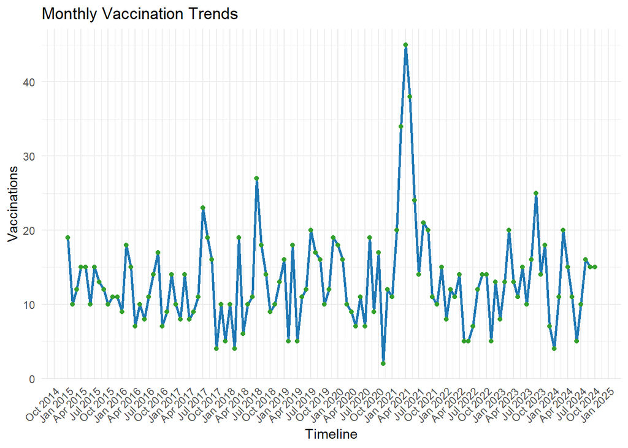

```r
vacc_1524 %>%
  count(vacc_year, vacc_month) %>%
  ggplot(aes(x = as.Date(paste(vacc_year, vacc_month, "01", sep = "-")),
             y = n)) +
  geom_line(color = "#1f78b4", linewidth = 1) +
  geom_point(color = "#33a02c") +
  labs(title = "Monthly Vaccination Trends",
       x = "Timeline", y = "Vaccinations") +
  scale_x_date(date_labels = "%b %Y", date_breaks = "3 months") +
  theme_minimal() +
  theme(axis.text.x = element_text(angle = 45, hjust = 1))
```

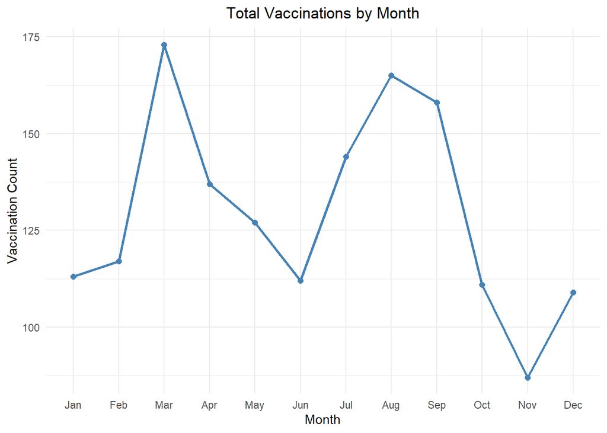

```r
vacc_1524 %>%
  mutate(month = month(vacc_date, label = TRUE, abbr = TRUE)) %>%  # Extract month from date
  group_by(month) %>%
  summarise(count = n(), .groups = "drop") %>%
  ggplot(aes(x = month, y = count, group = 1)) +

  geom_line(linewidth = 1, color = "steelblue") +
  geom_point(size = 2, color = "steelblue") +
  labs(
    title = "Total Vaccinations by Month",
    x = "Month",
    y = "Vaccination Count"
  ) +
  theme_minimal() +
  theme(
    plot.title = element_text(hjust = 0.5)
  )
```

## **Weekday Heatmap**

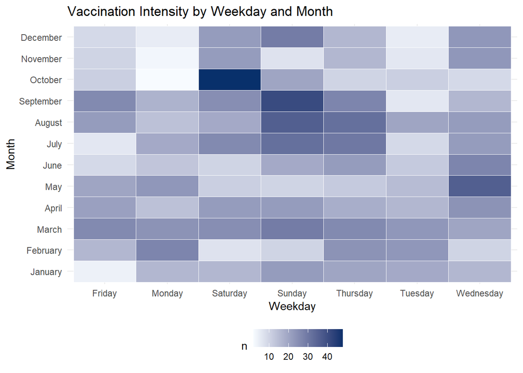

```r
vacc_1524 %>%
  count(vacc_month_name, vacc_weekday) %>%
  ggplot(aes(x = vacc_weekday, y = vacc_month_name, fill = n)) +
  geom_tile(color = "white") +
  scale_fill_gradient(low = "#f7fbff", high = "#08306b") +
  labs(title = "Vaccination Intensity by Weekday and Month",
       x = "Weekday", y = "Month") +
  theme_minimal() +
  theme(legend.position = "bottom")
```

## **Seasonal Vaccination Distribution**

Explore how vaccination services vary by season.

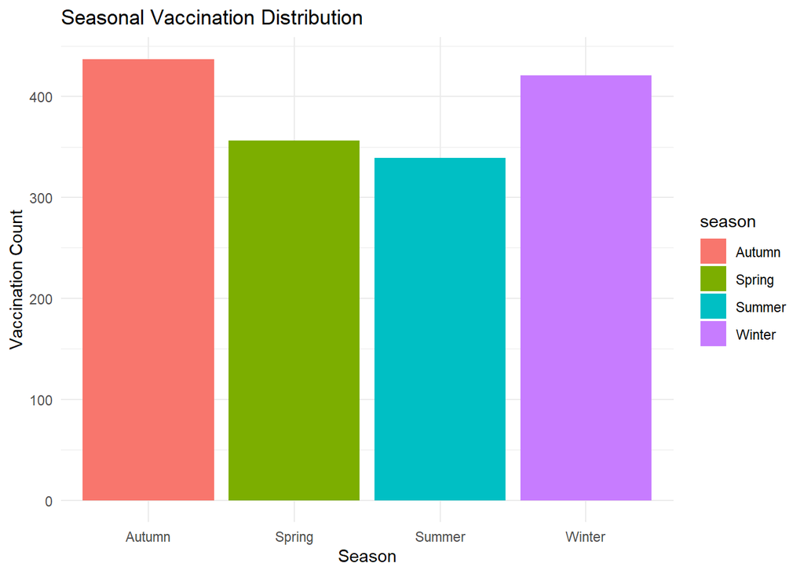

```r
vacc_1524 %>%
  mutate(month = as.numeric(format(vacc_date, "%m")),
         season = case_when(
           month %in% c(12, 1, 2) ~ "Summer",
           month %in% c(3, 4, 5) ~ "Autumn",
           month %in% c(6, 7, 8) ~ "Winter",
           month %in% c(9, 10, 11) ~ "Spring"
         )) %>%
  count(season) %>%
  ggplot(aes(x = season, y = n, fill = season)) +
  geom_col() +
  labs(
    title = "Seasonal Vaccination Distribution",
    x = "Season",
    y = "Vaccination Count"
  ) +
  theme_minimal()
```

## Vaccination proportion by year and race

If we’d like a stacked bar plot of the proportions

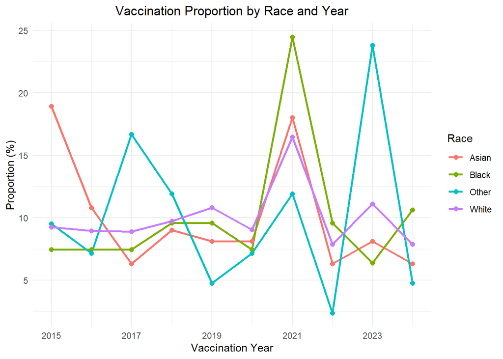

```r
# Proportion by vacc_year and race with cleaned race labels
df_plot_race <- vacc_1524 %>%
  mutate(
    race = ifelse(race %in% c("native", "other"), "Other", race),
    race = str_to_title(race),
    vacc_year = as.integer(floor(as.numeric(vacc_year)))  # Ensure whole number
  ) %>%
  group_by(race, vacc_year) %>%
  summarise(count = n(), .groups = "drop") %>%
  group_by(race) %>%
  mutate(
    total = sum(count),
    proportion = (count / total) * 100
  ) %>%
  ungroup()

# Line plot
ggplot(df_plot_race, aes(x = vacc_year, y = proportion, color = race)) +
  geom_line(linewidth = 1) +
  geom_point(size = 2) +
  scale_x_continuous(breaks = seq(min(df_plot_race$vacc_year), max(df_plot_race$vacc_year), by = 2)) +
  labs(
    title = "Vaccination Proportion by Race and Year",
    x = "Vaccination Year",
    y = "Proportion (%)",
    color = "Race"
  ) +
  theme_minimal() +
  theme(
    legend.position = "right",
    plot.title = element_text(hjust = 0.5)
  )
```

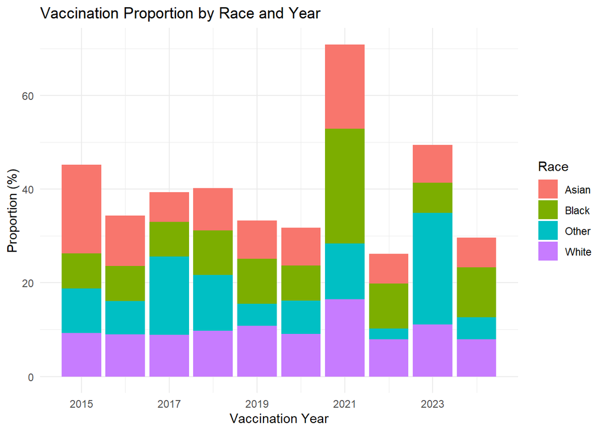

```r
# Bar plot
ggplot(df_plot_race, aes(x = vacc_year, y = proportion, fill = race)) +
  geom_bar(stat = "identity", position = "stack") +
  scale_x_continuous(breaks = seq(min(df_plot_race$vacc_year), max(df_plot_race$vacc_year), by = 2)) +
  labs(
    title = "Vaccination Proportion by Race and Year",
    x = "Vaccination Year",
    y = "Proportion (%)",
    fill = "Race"
  ) +
  theme_minimal()
```

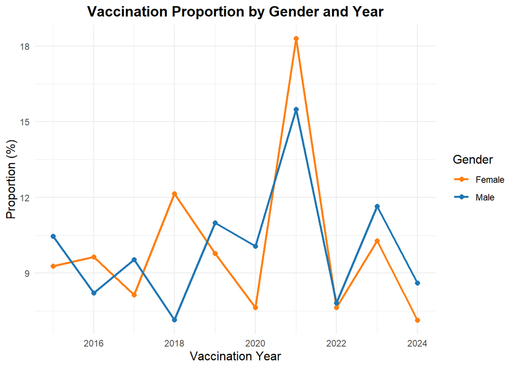

```r
# Proportion by vacc_year and gender
vacc_1524 %>%
  mutate(
    gender = case_when(
      gender == "M" ~ "Male",
      gender == "F" ~ "Female",
      TRUE ~ gender
    ),
    vacc_year = as.integer(vacc_year)  # Ensure year is whole number
  ) %>%
  group_by(gender, vacc_year) %>%
  summarise(count = n(), .groups = "drop") %>%
  group_by(gender) %>%
  mutate(
    total = sum(count),
    proportion = (count / total) * 100
  ) %>%
  ungroup() %>%

  ggplot(aes(x = vacc_year, y = proportion, color = gender)) +
  geom_line(linewidth = 1) +
  geom_point(size = 2) +
  scale_x_continuous(breaks = scales::pretty_breaks()) +  # Ensures whole number years
  labs(
    title = "Vaccination Proportion by Gender and Year",
    x = "Vaccination Year",
    y = "Proportion (%)",
    color = "Gender"
  ) +
  scale_color_manual(values = c("Male" = "#1f77b4", "Female" = "#ff7f0e")) +
  theme_minimal() +
  theme(
    legend.position = "right",
    plot.title = element_text(hjust = 0.5, size = 14, face = "bold"),
    axis.title = element_text(size = 12),
    legend.title = element_text(size = 12)
  )
```

## **Summary and Key Takeaways**

Best practices:

- Always validate date conversions
- Document time units clearly (days vs. months vs. years)
- Handle missing dates explicitly
- Consider time zones for multi-center studies

**References**

1. https://CRAN.R-project.org/package=dplyr
2. https://www.jstatsoft.org/article/view/v103i01
3. https://r4ds.hadley.nz/